# Statistics2, lab 1: 1-way ANOVA

Robert van Timmeren S4535553

March 29th, 2021

# 1 1. Load libraries and data

```r
# 1. Load the input file
library(car)
df = read.csv("lab1_translation_empathy.csv")
head(df)
```

```
##   X condition empathy
## 1 1        HT     4.0
## 2 2        HT     3.0
## 3 3        HT     3.6
## 4 4        HT     4.4
## 5 5        HT     4.2
## 6 6        HT     3.0
```

# 2 2. Investigate the dependent variable

I would expect that the groups all scored about the same, since I think that translation does not necessarily have impact on the empathy of a reader with the characters of that story. I could see the MT group score a little lower, since some context may be lost during the translation.

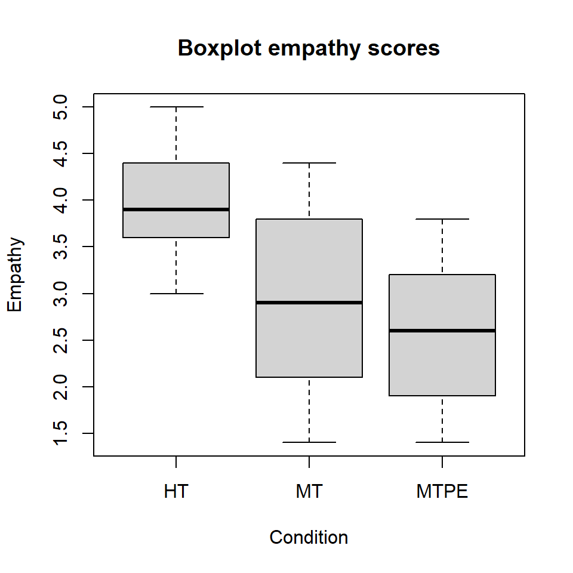

```r
# Boxplot of three groups
boxplot(df$empathy ~ df$condition, main = "Boxplot empathy scores", xlab = "Condition", ylab = "Empathy")
```

```r
# Check mean of each group and overall
tapply(df$empathy, df$condition, mean)
```

```
##    HT    MT  MTPE
## 3.920 2.925 2.600
```

```r
mean(df$empathy)
```

```
## [1] 3.144828
```

Apparently I was incorrect, and the HT group did also score higher in empathy. The only two groups their mean are fairly even.

# 3 3. Hypotheses

$H_0$: μ<sub>HT</sub> = μ<sub>MT</sub> = μ<sub>MTPE</sub>

$H_0$: not all of the μ<sub>i</sub> are equal

# 4 Test normality

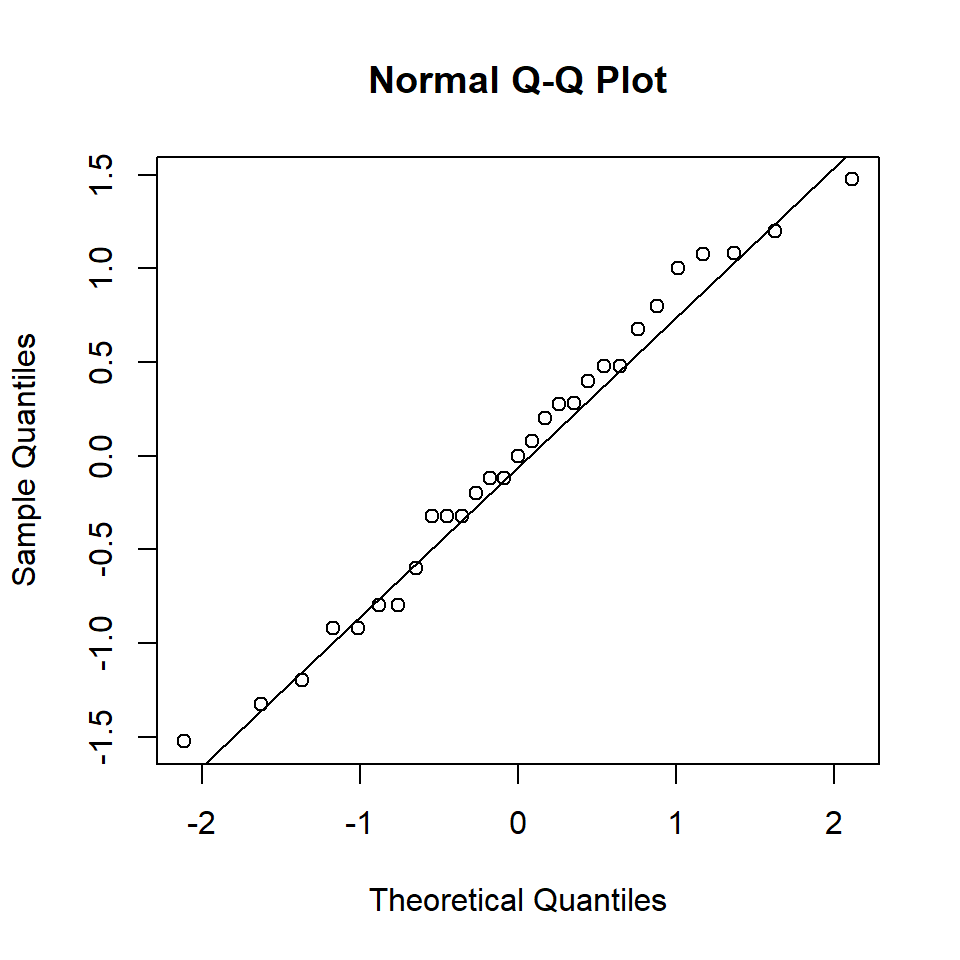

```r
df.aov <- aov(empathy ~ condition, data = df)
df.aov.res <- residuals(object=df.aov)

# Creating a q-q plot
qqnorm(y=df.aov.res)
qqline(y=df.aov.res)
```

```r
# Conducting Shapiro-Wilk test
aggregate(empathy ~ condition, data=df, function(x) shapiro.test(x)$p.value)
```

```
##   condition   empathy
## 1        HT 0.7150807
## 2        MT 0.7106916
## 3      MTPE 0.7213275
```

The data is assumed to be normally distributed, since all p-values of Shapiro-Wilk test are >= 0.05 (so in the Shapiro-Wilk test, the null hypothesis is accepted). The q-q plot also shows that the data seems to be normally distributed. The assumption of normality is fulfilled, because the data is normally distributed.

# 5 Test variance

```r
# Conduct Levene test (since data is normal)
leveneTest(df.aov)
```

```
## Levene's Test for Homogeneity of Variance (center = median)
##       Df F value Pr(>F)
## group  2  1.8181 0.1824
##       26
```

The variance of the data is homogeneous, since p is 0.1824, which is >= 0.05. So the null hypothesis of the Levene test that all variances in the different groups are equal is accepted. The assumption of variance is fulfilled, because the variance is homogeneous.

# 6 Test variance with Hartley’s test, by hand

```r
# a. Variance per group
# MT
var_mt <- (2.6-2.925)^2 + (3.2-2.925)^2 + (4.4-2.925)^2 + (3.6-2.925)^2 + (4-2.925)^2 + (2.6-2.925)^2 + (1.4-2.925)^2 + (1.6-2.925)^2

# HT
var_ht <- (4-3.92)^2 + (3-3.92)^2 + (3.6-3.92)^2 + (4.4-3.92)^2 + (4.2-3.92)^2 + (3-3.92)^2 + (5-3.92)^2 + (3.8-3.92)^2 + (4.4-3.92)^2 + (3.8-3.92)^2

# MTPE
var_mtpe <- (2.4-2.6)^2 + (3.6-2.6)^2 + (1.4-2.6)^2 + (2-2.6)^2 + (2.6-2.6)^2 + (1.8-2.6)^2 + (3-2.6)^2 + (2.8-2.6)^2 + (1.8-2.6)^2 + (3.4-2.6)^2 + (3.8-2.6)^2

var_mt / var_ht
```

```
## [1] 2.306278
```

2.3 < 6.94 (from a-level 0.05 table with n-1 = 7 and k = 3), so the variance is homogeneous. Meaning that this test does give the same result as the previous test.

# 7 1-way ANOVA

```r
df.aov <- aov(empathy ~ condition, data = df)
summary(df.aov)
```

```
##             Df Sum Sq Mean Sq F value  Pr(>F)
## condition    2  9.661   4.830   6.942 0.00384 **
## Residuals   26 18.091   0.696
## ---
## Signif. codes:  0 '***' 0.001 '**' 0.01 '*' 0.05 '.' 0.1 ' ' 1
```

P-value of 1-way ANOVA is 0.00384, which is < than 0.05. Since the p-value is lower than the α-level, the result is significant. Therefore we should reject the null hypothesis and accept the alternative hypothesis.

# 8 Effect size

```r
# R2 (SSG / SST)
SSG <- 10*(3.92-3.144828)^2 + 8*(2.925-3.144828)^2 + 11*(2.6-3.144828)^2


# SST = SSG + SSE
SSE <- var_mt + var_ht + var_mtpe
SST <- SSG + SSE
SST
```

```
## [1] 27.75172
```

```r
# Effect size
SSG / SST
```

```
## [1] 0.3481126
```

```r
# Adjusted R2
summary(lm(formula = empathy ~ condition, data = df))
```

```
##
## Call:
## lm(formula = empathy ~ condition, data = df)
##
## Residuals:
##    Min     1Q Median     3Q    Max
## -1.525 -0.600  0.000  0.480  1.475
##
## Coefficients:
##               Estimate Std. Error t value Pr(>|t|)
## (Intercept)     3.9200     0.2638  14.861 3.21e-14 ***
## conditionMT    -0.9950     0.3957  -2.515  0.01843 *
## conditionMTPE  -1.3200     0.3645  -3.622  0.00124 **
## ---
## Signif. codes:  0 '***' 0.001 '**' 0.01 '*' 0.05 '.' 0.1 ' ' 1
##
## Residual standard error: 0.8342 on 26 degrees of freedom
## Multiple R-squared:  0.3481, Adjusted R-squared:  0.298
## F-statistic: 6.942 on 2 and 26 DF,  p-value: 0.003839
```

R2 is 0.3481126 and adjusted R2 is 0.298.

# 9 Post-hoc test Bonferroni

```r
pairwise.t.test(x = df$empathy, g = df$condition, p.adjust.method = "bonferroni")
```

```
##
##  Pairwise comparisons using t tests with pooled SD
##
## data:  df$empathy and df$condition
##
##      HT     MT
## MT   0.0553 -
## MTPE 0.0037 1.0000
##
## P value adjustment method: bonferroni
```

# 10 Post-hoc test TukeyHSD

```r
TukeyHSD(df.aov)
```

```
##   Tukey multiple comparisons of means
##     95% family-wise confidence level
##
## Fit: aov(formula = empathy ~ condition, data = df)
##
## $condition
##           diff       lwr         upr     p adj
## MT-HT   -0.995 -1.978204 -0.01179584 0.0469038
## MTPE-HT -1.320 -2.225661 -0.41433882 0.0034440
## MTPE-MT -0.325 -1.288137  0.63813666 0.6829156
```

The function returns the differences between the group means. The greatest difference can be seen between MTPE and HT (-1.320), so that seems to correspond to the previous test. However, the p-value of MT and HT is < 0.05, meaning that MT and HT are significantly different. The outcome does not seem to agree on those two group.